# Plot Methods

‘ggspectra’ 0.2.1.9002

Pedro J. Aphalo

2017-05-02

## Introduction

Package `ggspectra` extends `ggplot2` with stats, geoms and annotations suitable for light spectra. It also defines `ggplot()` and `plot()` methods specialized for the classes defined in package `photobiology` for storing different types of spectral data. This vignette describes the use of these plot methods.

Although the package uses internally `ggplot2`, `photobiology` and `photobiologyWavebands` it does not re-export these packages, which need to loaded if used.

```r
library(ggplot2)
library(photobiology)
library(photobiologyWavebands)
library(ggspectra)
```

We bind two spectra into an object to be used later to demonstrate grouping.

```r
two_suns.spct <- rbindspct(list(sun1 = sun.spct, sun2 = sun.spct * 2))
```

We change the default theme.

```r
theme_set(theme_bw(10))
```

## Plotting spectra

The most automatic way of plotting spectral data stored in one of the classes defined in package `photobiology` is to use the `plot()`methods. These go much further than the `plot()` method defined in base-R for numeric data, as these classes store metadata that allows the automatic construction of axis labels as quantities and units are well defined.

Here we use the same example `source_spct` object from package `photobiology` used in the User Guide. In contrast to the examples in the User Guide, here we obtain with a very simple statement a complete annotated plot of the solar spectrum at ground level.

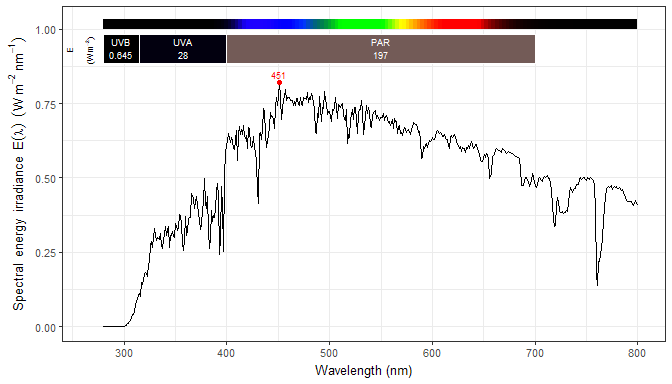

```r
plot(sun.spct)
```

Although the defaults provide a useful plot, the `plot()` methods accepts arguments for several parameters that allow to tweak the looks and contents of the plots without explicit manipulation of the spectral data.

### Summary quantities in labels

In this first example we pass `"mean"` as argument to `label.qty`, to print means instead of integrals in the labels. Note that the units and quantity labels for the waveband summaries have also changed.

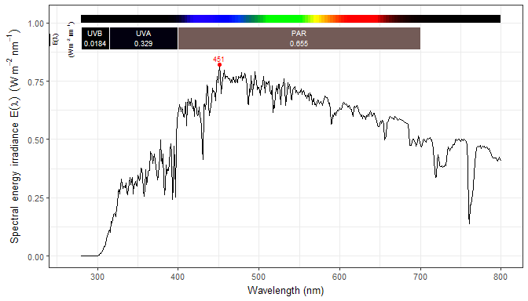

```r
plot(sun.spct, label.qty = "mean")
```

Two `label.qty` values need explanation. The first one, `"relative"` displays in labels the relative contribution of the integral of each waveband, to the sum of the integrals of all wavebands. The second one, `"contribution"` displays in labels the integral of each waveband divided by the integral of the whole spectrum. Consequently, this second option should be interpreted with caution, as the spectral data is unlikely in many cases to include the whole emission or absorption spectrum of a source.

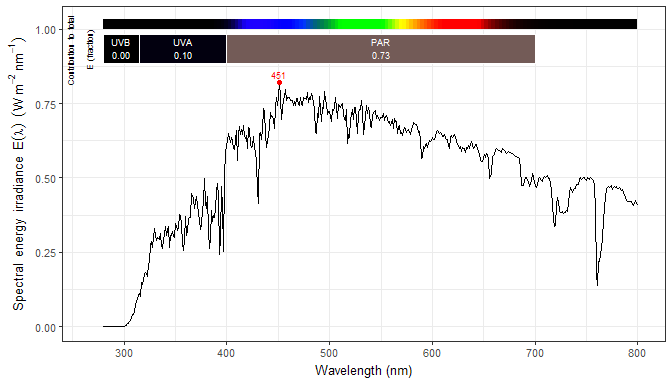

```r
plot(sun.spct, label.qty = "contribution")
```

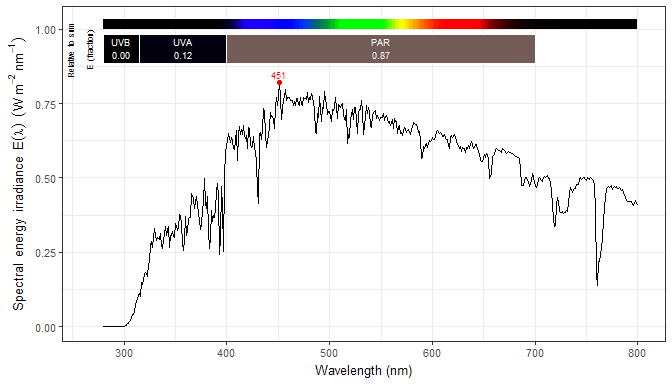

```r
plot(sun.spct, label.qty = "relative")
```

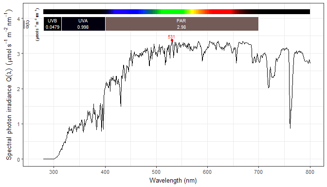

```r
plot(sun.spct, label.qty = "mean", unit.out = "photon")
```

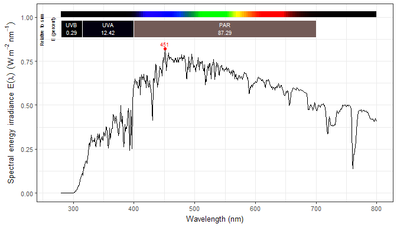

```r
plot(sun.spct, label.qty = "relative.pc")
```

We can change the basis of expression of spectral irradiance and irradiance from `"energy"` to `"photon"`. Be aware that by design, all values, summaries and spectral data will always use the same base of expression.

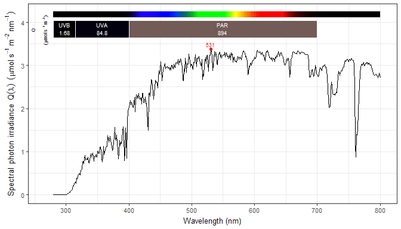

```r
plot(sun.spct, unit.out = "photon")
```

### Automatic annotations

Which *annotations* are included can be controlled through parameter `annotations`. These are passed as a vector of character strings, with three values with special meaning for the first element (with index = 1): `"="` means use only the annotations that follow in the vector, `"+"` means add to the default the annotations that follow, and `"-"` means remove the annotations that follow from the defaults. A `NULL` value means use defaults as is, `""` means no annotations, and `"reserve.space"` means no annotations, but expand axis limits and set identity scales ready for mannually adding annotations.

| annotation | default for classes | overrides |
| --- | --- | --- |
| “boxes” | all |  |
| “segments” | none | “boxes” |
| “color.guide” | all |  |
| “peaks” | all |  |
| “peak.labels” | none | “peaks” |
| “valleys” | none |  |
| “valley.labels” | none | “valleys” |
| “labels” | all |  |
| “summaries” | `source_spct`, `response_spct`, `filter_spct`, `reflector_spct` |  |

We can list all the annotations to be included in the plot, in which case `"="` is optional so as to maintain compatibility with earlier versions.

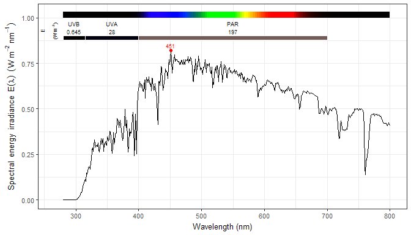

```r
plot(sun.spct,
     annotations = c("=", "segments", "labels", "summaries", "color.guide", "peaks"))
```

The same plot can be obtained by simply adding `"segments"`, as these override the default `"boxes"`.

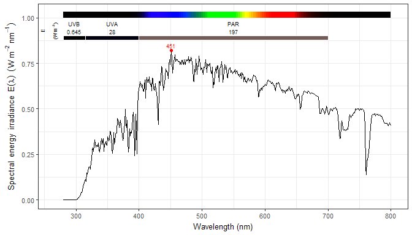

```r
plot(sun.spct,
     annotations = c("+", "segments"))
```

We can also *remove* some of the default annotations.

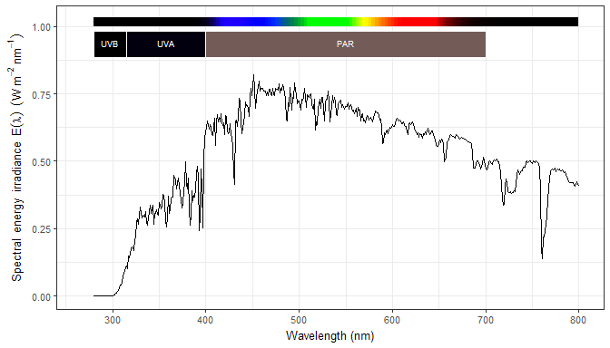

```r
plot(sun.spct, annotations = c("-", "summaries", "peaks"))
```

We add `"valleys"` as annotations, and control with `span` how near peaks and valleys are found.

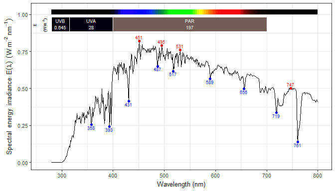

```r
plot(sun.spct, annotations = c("+", "valleys"), span = 41)
```

The annotations `"peak.labels"` and `"valley.labels"` overridde `"peaks"` and `"valleys"`. They use the *repulsive* geometry `geom_label_repel` from package ‘ggrepel’.

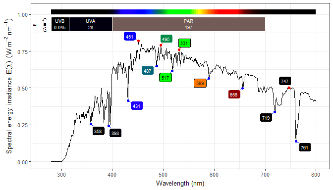

```r
plot(sun.spct, annotations = c("+", "peak.labels", "valley.labels"), span = 41)
```

Passing `""` as argument to `annotations` results in a plot with no annotations, and no *scales* set.

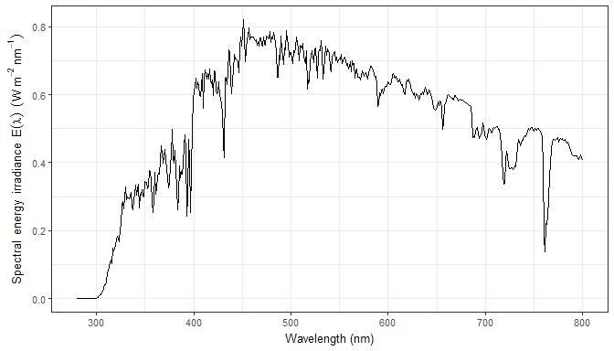

```r
plot(sun.spct, annotations = "")
```

Passing `"reserve.space"` as argument to `annotations` results in a plot with no annotations, but *scales* set and expanded so as to receive annotations.

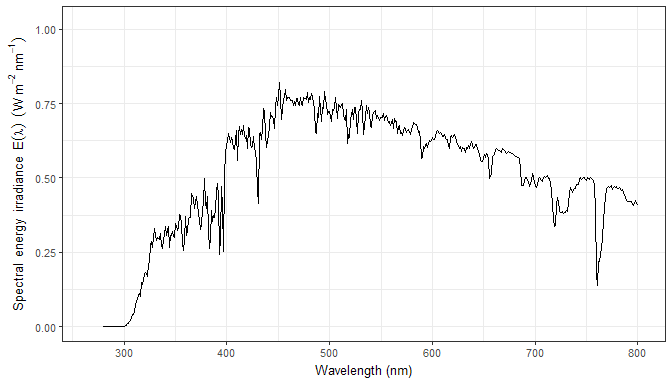

```r
plot(sun.spct, annotations = "reserve.space")
```

The size of the font used for the annotations is controlled by argument `text.size`.

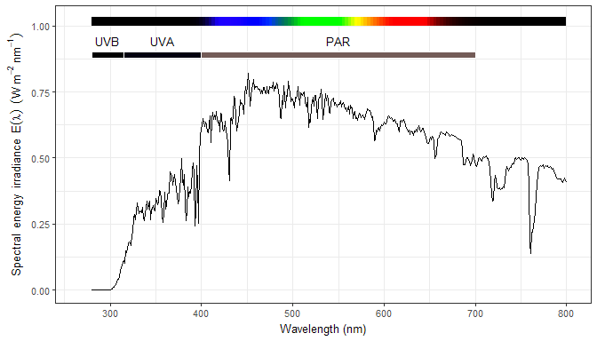

```r
plot(sun.spct, annotations = c("=", "segments", "labels", "color.guide"),
     text.size = 3.5)
```

Arguments `range` and `w.band` play very different roles. The first one determines the `range` of wavelengths to include in the data plotted, which is slightly different to the effect of `ggplot2::xlim()` as `range` is used to *trim* the spectral data **before** passing it to `ggplot`, using interpolation when needed (see `photobiology::trim_wl()`). The second one, `w.band` is only used for the *annotations* and decorations. It should be however noted, that a `waveband` object is a valid argument for both `range` and `w.band`.

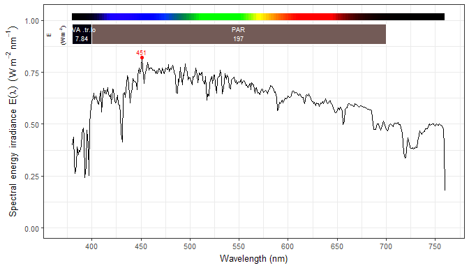

```r
plot(sun.spct, range = VIS())
```

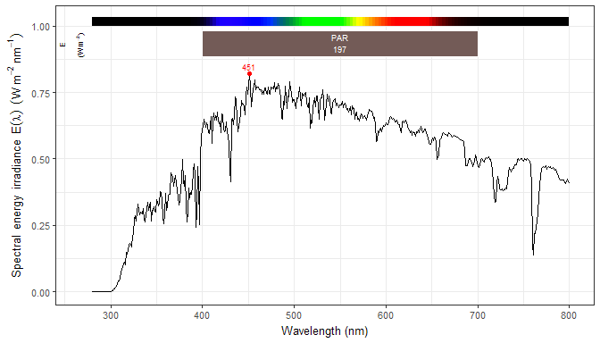

```r
plot(sun.spct, w.band = PAR())
```

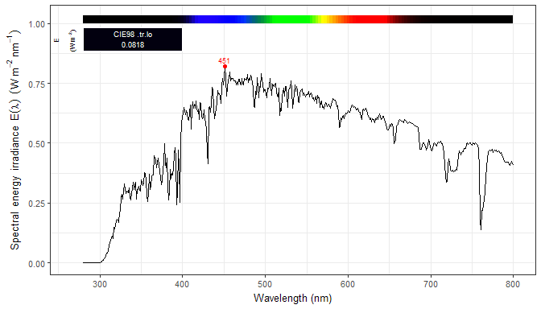

```r
plot(sun.spct, w.band = CIE())
```

`NULL` as argument for `w.band` is replaced by a waveband covering the full range of the spectral datat.

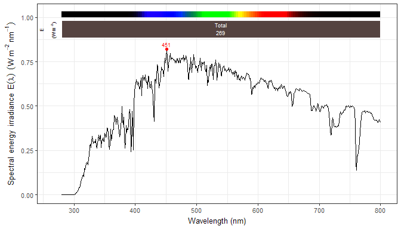

```r
plot(sun.spct, w.band = NULL)
```

The *whole range* is the range plotted, which is controlled by the argument passed to `range`.

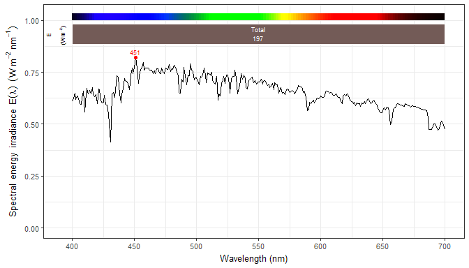

```r
plot(sun.spct, w.band = NULL, range = c(400,700))
```

The argument passed to `range` can be a `waveband` or and spectrum, in which case their wavelength range is used.

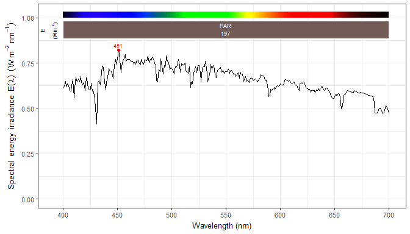

```r
plot(sun.spct, w.band = NULL, range = PAR())
```

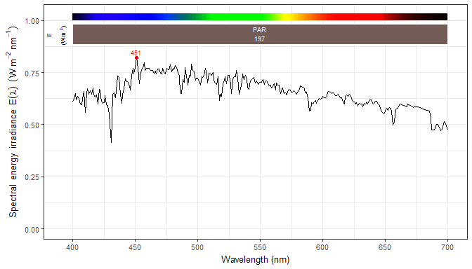

```r
plot(sun.spct, w.band = PAR(), range = PAR())
```

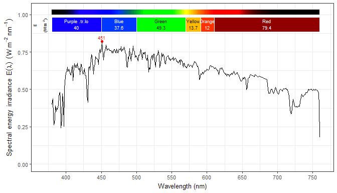

```r
plot(sun.spct, w.band = VIS_bands(), range = VIS())
```

The time unit is also stored in the metadata, as demonstrated here. The units in axis labels have changed to the units used in the spectral data.

```r
getTimeUnit(sun.daily.spct)
```

```
## [1] "day"
```

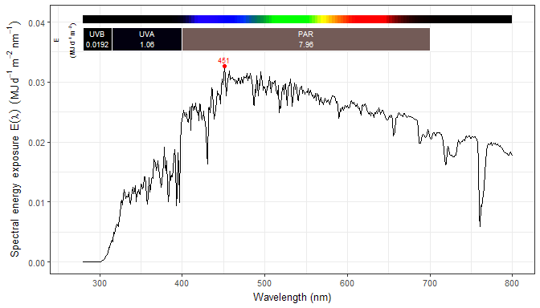

```r
plot(sun.daily.spct)
```

Even though the `plot()` methods can return a finished plot, the returned object is a `ggplot` object and can be built upon by adding additional elements like *facets*, *aesthetics* and even additional *layers*.

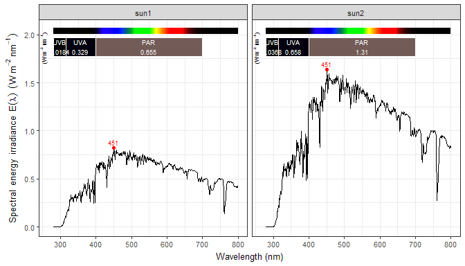

```r
plot(two_suns.spct, label.qty = "mean") + facet_wrap(~spct.idx)
```

When using grouping the `"summaries"` annotation would be overplotted, and needs to be suppressed.

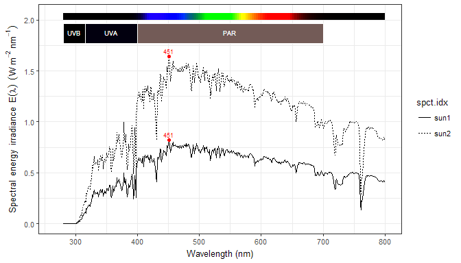

```r
plot(two_suns.spct, annotations = c("-", "summaries")) +
  aes(linetype = spct.idx)
```

It is possible to construct and bind the spectra on-the-fly.

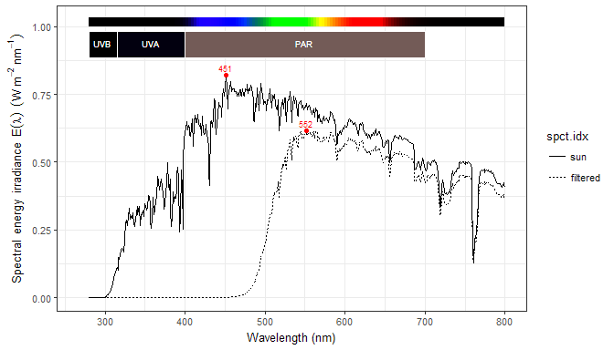

```r
plot(rbindspct(list(sun = sun.spct, filtered = yellow_gel.spct * sun.spct)),
     annotations = c("-", "summaries")) +
  aes(linetype = spct.idx)
```

In the examples above the `source_spct` object `sun.spct` was used. The `plot()` methods for other spectral classes have slight differences. We show some examples for `filter_spct` objects.

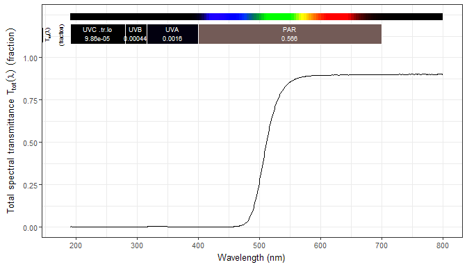

```r
plot(yellow_gel.spct, annotations = c("-", "peaks"))
```

By default transmittance, reflectance and absorptance are expressed as fractions of one, as in the plot above, but optionally percents can be plotted.

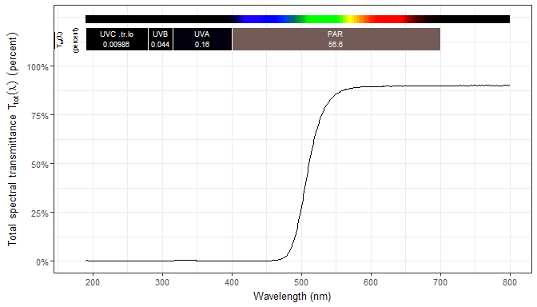

```r
plot(yellow_gel.spct, pc.out = TRUE, annotations = c("-", "peaks"))
```

In many cases it is possible to convert on-the-fly the quantity plotted.

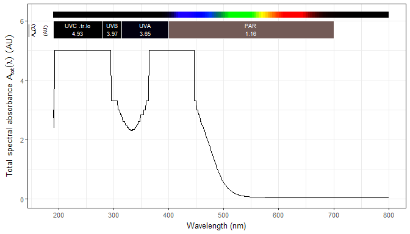

```r
plot(yellow_gel.spct, plot.qty = "absorbance", annotations = c("-", "peaks"))
```

We add a *guessed* spectral reflectance to the data object to allow the estimation of internal absorptance.

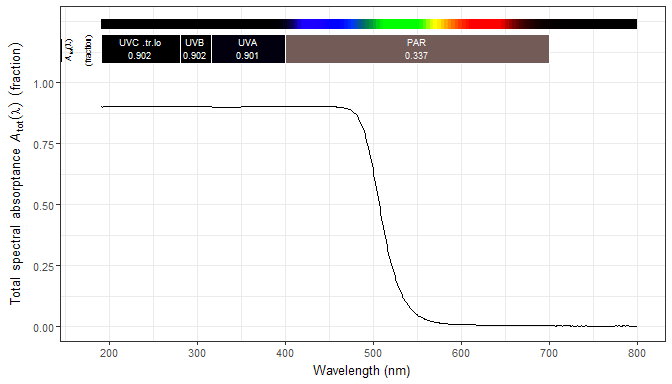

```r
yellow_gel.spct$Rfr <- 1 - max(yellow_gel.spct$Tfr)
plot(yellow_gel.spct, plot.qty = "absorptance", annotations = c("-", "peaks"))
```

If one really needs to, one can add a suitable *stat* using ‘local’ data. A peak annotaion could be added manually.

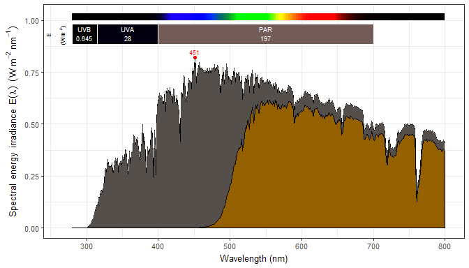

```r
plot(sun.spct) + geom_spct(fill = color(sun.spct)) +
  geom_spct(data = yellow_gel.spct * sun.spct, color = "black",
            fill = color(yellow_gel.spct * sun.spct))
```